# Multivariate Analysis

2026-02-19

# Ordination

Ordination is arranging items along a scale.

Generally done as a way to summarize complex relationships, to extract one or a few dominant patterns from many possible patterns.  
Ordination is generally thought of as a means of generating hypotheses about underlying mechanisms, but can also be used to test hypotheses.

Ordination helps to:  
- select the most important factors from multiple factors imagined or hypothesized  
- separate strong, important patterns from weak ones  
- reveal unforeseen patterns and suggest unforeseen processes

## Ordination as “data reduction”

Summarize data set contianing multiple variables into a smaller number of composite (synthetic) variables  
Results in continuous synthetic variables (axes)  
After the variables are extracted, we attempt to relate them to *other* variables.

For example:  
One might summarize a matrix of resource use by species into a few dominant patterns, which are then correlated to characteristics of those species (longevity, size, reproduction mode, etc.)

## Ordination Diagrams

Typically 2-dimensional plot of one synthetic variable against another.

The distance between the points are proportional to the underlyikng distance measure.  
Points may respresent any number of things, depending on study design (sample units, individuals, species, quadrates, etc.)

## Interpretation

Interpretation is about relating variables of interest to the ordinations results.

**Two main methods:**  
- Overlays  
- Correlations  
These approaches can be used to detect patterns in the ordination.

*Overlays:* are a flexible way to see if a variable is patterned on an ordination… not limited to detecting only linear relationships.  
Many overlays are possible:  
- Different symbols for different classes of points  
- Related points enclosed with loops  
- Sizes of symbols proportional to the magnitude of the variable used as an overlay.

## Criteria for evaluating ordination quality

No single criterion exists for evaluating the quality of an ordination.

A combination of criteria generually used:  
- Proportion of variance explained  
- Interpretability  
- Strength of relationships to a second matrix

**Proportion of variance explained**  
- some ordination methods have this metric built-in (PCA)  
- others require more complicated calculations (MDS)

**Interpretability**  
- Does the ordination make sense in terms of the question posed?

**Strength of the relationship to a second matrix**  
- We often know something in advance about the relationship between variables in the analysis  
- If the ordination does not reflect what seems obvious about hte system, then should reevaluate assumptions and methodology (are there outliers, etc.)

# PCA

Also sometimes referred to as a “Factor Analysis”  
*Objective*  
- Represent a data set containing many variables with a smaller number of composite variables (“components” or “axes”)  
- The most interesting and strongest covariation among variables emerges in the first few axes (components)…hence “principal components”

**When to use it?**  
Approximately linear relationships among variables  
- in some cases data can be transformed  
Sample size  
- rule of thumb: at least 5 sample units for each observed variable (should only analyze elongate matrices (i.e. more rows than columns))  
- Good estimate of correlation structure among variables is necessary (smaller sample sizes OK if correlation structure is **strong**).  
Normality  
- If making statistical inferences…normality is important  
- Less important if goals are descriptive

Outliers  
- Exert great influence on the correlation coefficients and thus the PCA results

## How it works

Principal componenets are the underlying structure in the data.  
They represent directions explaining the most variance.  
To find the direction explaining the most variance, find the straight line minimizing the deviation *perpendicular* to the line.  
*Eigenvectors* and *Eigenvalues* can be constructed from the data matrix  
- determine the direction and magnitude of variation explained by the PC  
*Eigenvectors* and *Eigenvalues* exist in pairs: every eigen vector has a corresponding eigenvalue.  
Eigenvector is the direction  
Eigenvalue is a number describing how *much* variance exists in the direction of the eigenvector.

*Principle components are orthogonal to all others.

*Calculating PC Scores:* standardized score to reflect magnitude and direction of variation in new composite variable.

Need to couple other metric for calculation:  
*Loading (component coefficients):* correlation between the original variable and composite factor  
- key to understanding underlying nature of a particular factor  
Sum of the products of the standardized original variables (i.e. deviation of each value from the mean) and the loadings for these variables.

# Nonmetric Multidimensional Scaling (NMDS)

## How it Works

_In most ordinations:__  
1. many axes are calulated, but only a few are viewed  
2. solutions are analyytical, result in a single unique solution  
3. eigenvalue-eigenvector technique  
4. make specific assumptions: i.e. linearity

**Two principal drawbacks to NMDS:**  
1. The analysis is slow, particularly for large datasets  
2. Because it is a numerical optimization, it can fail to find the **true** best solution.

## Computation

1. Starts with a matrix of n rows of samples by p columns of variables
2. From this, an n x n matrix of pairwise distances among all samples i scalculated  
   NMDS is performed *on the distance matrix*  
   Choose the desired number of *m* dimensions (typically 2)  
   First, software constructs an initial configuration of the smaples in the m dimensions:
- initial configureations should be based on another ordination, or copmletely randomly
- the final ordination is partly dependent on the initial configuration  
  –> generally one runs several ordinations, each starting from a different random configureation

The distances among samples in the the random config are calculated and regressed against the original distance matrix producing *predicted ordination distances*  
In a perfect ordination, all ordinated distances would fall **exactly** on the regression  
The goodness of fit of the regression is measured using the sujm of the squared differences between the ordination-based distances (your random configuration) and predicted distances from regression  
- goodness of fit is called **stress** (lower the better)  
The fit is improved by moving positions of samples in ordination space by a small amount in the direction where the change in stress is the **steepest**  
After this modification, a new distance matrix is calculated from this new configuration, regression performed again, and *stress recalculated*  
Process is repeated until some tolerance level is reached, (i.e. minimal acceptable level of stress) or until the process converges (*fails to find any lower levels of stress)

## NMDS Theory

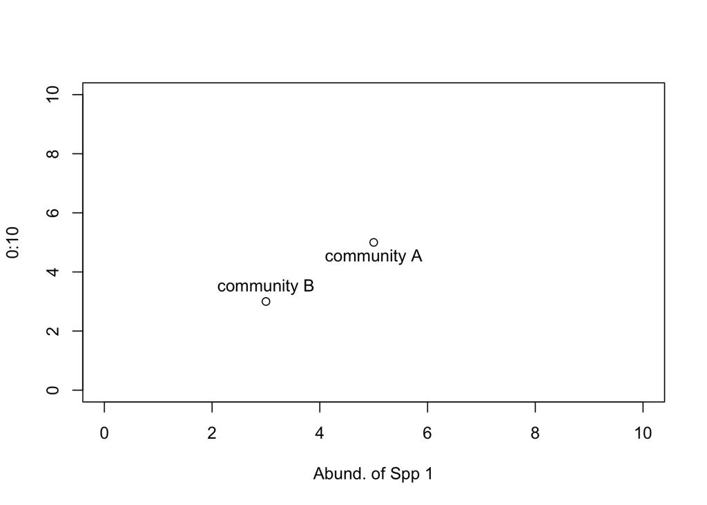

```r
plot(0:10,0:10, type = "n", xlab = "Abund. of Spp 1")
points(5,5); text(5,4.5, labels = "community A")
points(3,3); text( 3,3.5, labels = "community B")
```

This gets **insanely** harder with an increase in species (= an increase in axes)

```r
library(scatterplot3d)
d = scatterplot3d(0:10, 0:10,0:10, type = "n", xlab = "Abund of Spp 1",
                 ylab = "Abund of Spp 2", zlab = "Abund of Spp 3"); d
```

[output not shown]

[output cut: 114 more lines]

[output not shown]

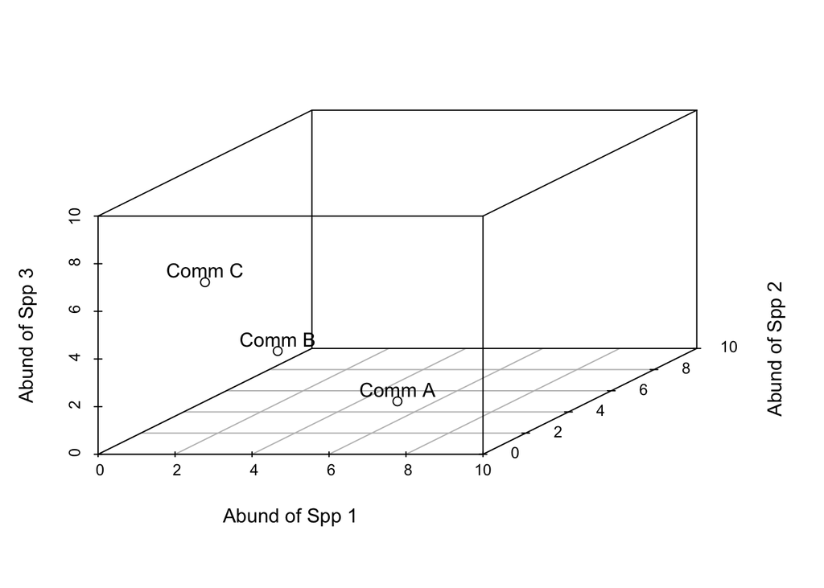

```r
d$points3d(5,5,0); text(d$xyz.convert(5,5,0.5), labels = "Comm A")
d$points3d(3,3,3); text(d$xyz.convert(3,3,3.5), labels = "Comm B")
d$points3d(0,5,5); text(d$xyz.convert(0,5,5.5), labels = "Comm C")
```

# MRPP and perMANOVA

**MRPP:** multi-resposne prumutational procedure  
- Both analyses are used to test whether groups defined in an ordination differ significantly from one another  
- Both utilize distance matrices  
- Both are non-parametric (i.e., no distributional assumptions)

## MRPP

Tess whether the mean within-group dissimilarity is smaller than expected.  
The test statistic, ∂, is simply the mean dissimilarity between pairs of sample units from the same group. It can be 0 or positive.  
Statistical significance focuses on the left tail of the distribution obtained from permutations of the rouping factor.  
An effect size, *A*, is also calculated and relates the observed ∂ to its expected values if the grouping factor was not helpful.  
MRPP **cannot** accomodate complex designs.

### How it works:

1. Convert the data matrix to a dissimilarity matrix –> calculate the mean distance within each group
2. Calculate the test statistic (the observed ∂) as the average of the mean distance within each group, weightin by sample size if necessary.
3. Assess statistical significance via a permutation test:
   1. Shuffle the group identities
   2. Recalculate ∂. Save this value.
   3. Re-shuffle and recalculate the specified number of times.  
      The permutations produce a sampling distribution of ∂  
      Calculate the P-value as the proportion of permuations that yielded ∂ equal or smaller than the observed ∂.

### Effect size, A

Defined as the chance-corrected within-group agreement.  
A = 1- (observed del/expected del)

## perMANOVA

Test the null hypothesis that the centroids and dispersion of groups are equivalent for all groups.  
In ecological terms, this means that:  
- there are no differences in the composition **and/or**  
- Relative abundances of species between the defined groups

Calculates a “pseudo F-ratio” similar to typical ANOVA  
In this case it compares…  
- sum of squared distances among groups divided by sum of the squared distances within groups.

### How it works

1. Calculates all pairwise distances in the entire dataset
2. Calculates F (observed)
3. It then permutes group identities, and recalculates F based on the permuted data
4. It repeats the permutation step x-times
5. The significance test is the fraction of permuted F that are greater than or equal to the observed F